# EAI Practicum 2.2

## Classification Problems I.

In the following exercise we’ll use the FIFA data set containing information on 19 239 players enrolled in the season of 22, including columns related to: player’s `role`, `player_positions`, `preferred_foot` and `skills`.

### Modelling Aims

Our goal is to discriminate **offensive** from **all other players** based on information we have on them, such as **skill** characteristics, **foot preference**, etc. That means we will create an ordinary logistic regression model to perform a binary classification of football players.

The process of fitting a logistic regression model will require from you to:

- understand your data,
- chose the right modeling function (logistic, poisson, etc.),
- capture and process the information from an object created by the modelling function,
- understand what logistic model delivers and how decision rules work on modelled probabilities,
- evaluate error of a model fit, and when needed, refine the model,
- validate your findings on fresh data.

### Data Loading

**Task 1:** Load `players_22.csv` data into R by completing the missing code.

```r
library(tidyverse)
library(magrittr) # Pipe implementation for R
library(data.table) # Implements %like%

setwd("...") # Set the correct path to players_22.csv
data <- read_csv("players_22.csv", col_names = TRUE, num_threads = 4) # Read data into R
data # Check that data are properly loaded
```

### Data Transformation

**Task 2:** A quick glance onto data tells us that there are several `player_positions` per record. To classify a player into one of four classes — *offense*, *defense*, *midfielder* and a *goal keeper* — use your code from a previous exercise.

```r
data %<>% mutate(
  role = case_when(
    ...
  )
)
```

**Task 3:** Logistic regression models require the dependent variable to be one-hot encoded. Your task is to create a new column `role_oneHot`, containing 1 for offensive players and 0 for other players. Restrict the dataset to only columns you need.

```r
data %<>%
  mutate(role_oneHot = ...) # 1 = offensive player, 0 = every other player
```

### Data Exploration

In the previous exercise, we have shown that if you are an offensive player, pretty much every skill positively correlates with your `overall` value (Y axis). Let’s revisit these data once again. This time, we will plot `skill_dribbling` on X axis and color-code four player positions.

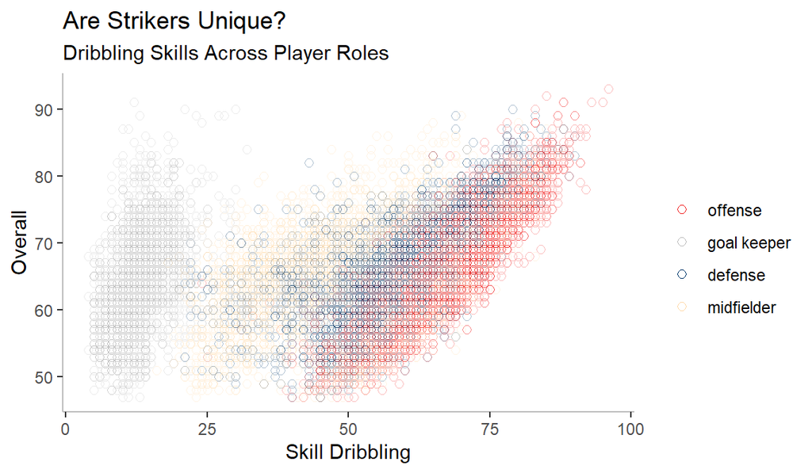

However, the distribution of skill points is role-dependent. You will rightly assume that top strikers, wingers and forwarders will have dribbling skills almost maxed out. Goal keepers, not so much.

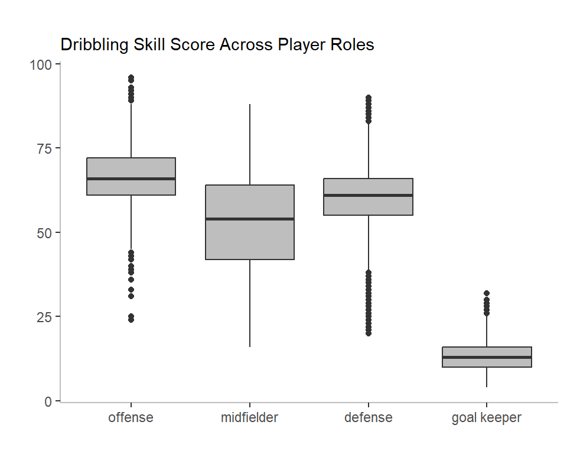

The box also plot hint us that we can use `skill_dribbling` attribute to separate offensive players and goal keepers almost perfectly. For every other player role, you have to make compromises.

### Hypothesis Formulation

> Technically speaking, the word “hypothesis” is a Greek word that means “an assumption subject to verification”.

Here, we will use the logistic function to **predict the player’s role** by regressing onto his **dribbling skills** and information about **preferred foot**. We assume that there might be a relationship between higher `skill_dribbling` values and the chance of a footballer playing in offense.

To make things clean, we will formulate two hypotheses:.

- H<sub>0</sub>: Higher dribbling skill value is not enough to classify a player as an offensive player (vs. player playing any other position).
- H<sub>0</sub>: Playing with left foot has no impact on the player’s role.

Remember that the null hypothesis is always stated in the negative. This is because we will build a logistic regression model to prove one, both or none of the H<sub>0</sub> hypotheses are true.

### Model Fitting

In logistic regression,

- we work with a **binary outcome**, such as “yes/no,”.
- The goal is to predict the **probability** of the positive outcome (e.g., “being offensive player”) based on the predictor variables.

The hypotheses will hold true, if we can separate offensive players from the rest based on `skill_dribbling` values and/or playing foot preference. If no clear distinction can be made, then it will be imperative to set a line that can minimizes the miss-classification rate of both classes.

Logistic regression is implemented by the `glm()` function with the following syntax:

```r
glm(formula, data, family = binomial)
```

where **formula** is symbolic. The **family** parameter stipulates the exact form of the `glm()` function.

**Task 4:** Create a *multiple* logistic regression model to evaluate both hypotheses in one go. Capture the model data into an object and call it (not surprisingly) `model`.

```r
model <- ... # Fill in your code here.
```

Check the type/class of the `model` object. Apply `summary()`, `str()` and `View()` and `plot()` to review its content. Do you get any meaningful readouts from these functions?

### The Logistic Function

The logistic function refers to the S-shaped curve that models the **probability** of a player’s class, thus ranging between 0 and 1. 0 means that there is no chance of a player ever playing in attack, and 1 means that the player will always play in offense.

**Task 5:** Visualize how the logistic function fits onto our data by completing the following code. Without knowing much about the *grammar of graphics* functions, fill in only variables needed for X and Y axis to be specified.

[figure not shown]

```r
data %>%
  ggplot(., aes(...)) + # Define variables for X an Y axix in aes()
  geom_point(position = position_jitter(width = 0.3, height = 0.06),
             alpha = 0.05,
             shape = 1,
             size = 1.5) +
  stat_smooth(method = glm, method.args = list(family = binomial)) +
  ggtitle("Dribbling Skill Across Player Roles",
          subtitle = "Offensive players: top, Other players: bottom")
```

The logistic function flips to the other side when the `skill_dribbling` attribute is about 60-ish (which equals to the probability of ~ 0.5). It is not a perfect flip, suggesting that we have to deal with a lot of miss-classified observations.

**Task 6:** Adapt the previous code to discriminate offensive players only from goal keepers. Has the shape of the S-function changed? If yes, why?

### Interpreting Model Parameters

**Task 7:** Use knowledge from linear regression exercise to retrieve the coefficients of the logistic function. Interpret your findings. You should be intrepreting values like these, or similar.

```
## # A tibble: 3 × 5
##   term                     estimate std.error statistic      p.value
##   <chr>                       <dbl>     <dbl>     <dbl>        <dbl>
## 1 (Intercept)               -6.23     0.120      -51.9  0
## 2 data$skill_dribbling       0.0927   0.00179     51.7  0
## 3 data$preferred_footRight   0.209    0.0390       5.36 0.0000000819
```

- What does the intercept and slope mean in a logistic function setting?
- In which units are the coefficients presented?
- What is the (*…fill in the appropriate unit…*) of a player being offensive if his the `skill_dribbling` is 0?
- How much this (*…fill in the appropriate unit…*) changes with an increase (or decrease) in `skill_dribbling` by 1?
- Has a playing foot preference any effect on player’s class?

### Probabilities and Probability Cut-Offs

The coefficients of the logistic regression are not really useful in practice, so we will work with model probabilities instead. The key thing at this stage is to convert them into discrete binary outcomes — player classes, that is. You can do it by setting up a **decision rule** that classifies

- a player to play in offense if his probability is >= 0.5,
- and a player to play in defense if his probability is < 0.5.

The conversion process can be hard to imagine, so let’s describe the relationship between data, player classes, probabilities and probability cut-offs on the following figure.

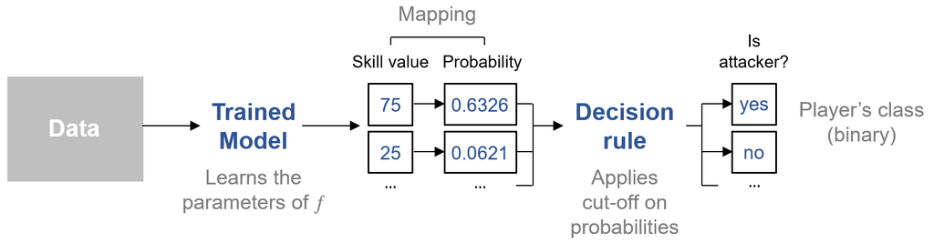

To turn probabilities into player classes, you need to:

- fit a logistic function onto the data.
- The function shape will be used to estimate class 1/“yes” probabilities for every player. Class 1 is determined by one-hot encoding during data transformation phase. In your case, it is offense.
- Apply the cut-off to probabilities. If their probability is less that 0.5, the player will be classified as a defensive player. Otherwise, the player will be classified as an offensive player.

**Task 8:** Find where the probabilities are stored inside `model`. Save them as `model.probabilities` and print first 10 values.

```r
 model.probabilities <- ... # Fill in your code here.
```

```
##           1           2           3           4           5           6
## 0.935518990 0.865750722 0.894931666 0.942207030 0.894931666 0.007343613
##           7           8           9          10
## 0.931238155 0.037792224 0.016760293 0.842693452
```

**Task 9:** Convert `model.probabilities` into one-hot-encoded classes using a cut-off value of 0.5. Save your result as `glm.prediction`.

```r
glm.prediction <- ... # Fill in your code here.
```

List first 10 values:

```
##  [1] 1 1 1 1 1 0 1 0 0 1
```

### The Contingency Table

**Task 10:** Perform a cross-tabulation of observed and predicted classes and calculate the associated statistics. You can use either the `table()` function with one-hot-encoded (`data$role_oneHot`) and predicted classes (`glm.prediction`), or get all work done with the `confusionMatrix()` function from the **caret** package.

```r
library(caret)
confusionMatrix(as_factor(glm.prediction), as_factor(data$role_oneHot), positive = "1")
```

```
## Confusion Matrix and Statistics
##
##           Reference
## Prediction    0    1
##          0 9372 3201
##          1 2580 4086
##
##                Accuracy : 0.6995
##                  95% CI : (0.693, 0.706)
##     No Information Rate : 0.6212
##     P-Value [Acc > NIR] : < 2.2e-16
##
##                   Kappa : 0.3507
##
##  Mcnemar's Test P-Value : 3.51e-16
##
##             Sensitivity : 0.5607
##             Specificity : 0.7841
##          Pos Pred Value : 0.6130
##          Neg Pred Value : 0.7454
##              Prevalence : 0.3788
##          Detection Rate : 0.2124
##    Detection Prevalence : 0.3465
##       Balanced Accuracy : 0.6724
##
##        'Positive' Class : 1
##
```

In the next exercise, we will explore this table in detail.